# Diversificación sectorial y eficiencia productiva en Ecuador, 2000–2024

Una evaluación con el índice Herfindahl–Hirschman y análisis envolvente de datos con inferencia bootstrap

Autor/a

Afiliación

Econ. Vinicio Arcos

Replicación y extensión metodológica de Siddiqui & Afzal (2022)

Fecha de publicación

17 de junio de 2026

Resumen

La dependencia de recursos primarios y la escasa transformación estructural son rasgos persistentes de la economía ecuatoriana. Este trabajo replica y extiende el enfoque de Siddiqui y Afzal (2022) para los Emiratos Árabes Unidos aplicándolo a Ecuador en el periodo 2000–2024. Primero, se mide la concentración sectorial con el índice Herfindahl–Hirschman (HHI) sobre el Valor Agregado Bruto de siete ramas ISIC de la base de Cuentas Nacionales de la UNSD. Segundo, se evalúa la eficiencia técnica con un modelo de análisis envolvente de datos (DEA) CCR orientado a insumos, especificado como una frontera de producción genuina —trabajo (empleo) y capital (formación bruta de capital fijo) como insumos independientes que generan valor agregado— con la unidad de decisión definida como el par sector-año. Tercero, se cuantifica la incertidumbre y se corrige el sesgo al alza de las eficiencias DEA mediante el bootstrap homogéneo de Simar y Wilson (1998). Los resultados muestran una economía moderadamente diversificada cuyo HHI aumentó de 0,182 en 2000 a 0,214 en 2024, con una concentración creciente entre 2015 y 2020, y una eficiencia técnica heterogénea entre ramas: construcción y minería-utilities operan cerca de la frontera, mientras que agricultura y transporte-comunicación quedan rezagadas. La corrección por sesgo confirma el sesgo determinista del DEA y delimita comparaciones robustas. Se discuten implicaciones de política para la transformación productiva.

Palabras clave

diversificación sectorial, índice Herfindahl-Hirschman, análisis envolvente de datos, bootstrap Simar-Wilson, Ecuador, eficiencia técnica

# 1 Introducción

La diversificación de la estructura productiva es uno de los determinantes clásicos del desarrollo económico sostenido. Desde los aportes seminales sobre el cambio estructural (Kuznets, 1955; Lewis, 1954) hasta la literatura contemporánea sobre complejidad económica (Hausmann et al., 2007; Hidalgo & Hausmann, 2009), la evidencia sugiere que las economías que amplían y sofistican su canasta productiva tienden a crecer más rápido y a ser menos vulnerables a choques externos. La contracara —la concentración en pocos sectores, típicamente basados en recursos naturales— se asocia con volatilidad macroeconómica y, en ciertos contextos, con la denominada “maldición de los recursos” (Gylfason, 2001; Lederman & Maloney, 2007; Sachs & Warner, 1995).

Ecuador es un caso paradigmático de esta tensión. Su matriz productiva ha estado históricamente anclada en la extracción y exportación de petróleo y productos primarios, con episodios recurrentes de vulnerabilidad fiscal y externa asociados a la volatilidad de los precios de las materias primas (Rivera Velasco, 2025; UNCTAD, 2019). Comprender el grado de concentración sectorial de su economía, y la eficiencia con que cada sector transforma trabajo y capital en valor agregado, es relevante tanto para el diagnóstico académico como para el diseño de política industrial (Benhassine et al., 2019; Rodrik, 2004).

Este trabajo replica y extiende metodológicamente el estudio de Siddiqui & Afzal (2022), quienes evaluaron la diversificación sectorial de los Emiratos Árabes Unidos hacia una economía del conocimiento combinando el índice Herfindahl–Hirschman (HHI) con el análisis envolvente de datos (DEA). Aplicamos ese marco a Ecuador en el periodo 2000–2024 y aportamos tres mejoras metodológicas: (i) una partición sectorial con poder discriminante real, basada en siete ramas ISIC del Valor Agregado Bruto; (ii) un DEA especificado como frontera de producción genuina, con insumos independientes y un número de unidades de decisión que satisface holgadamente la regla de adecuación; y (iii) inferencia estadística mediante el bootstrap de Simar & Wilson (1998), que corrige el sesgo determinista de las eficiencias DEA y construye intervalos de confianza.

El resto del documento se organiza así. La Sección 2 revisa la literatura sobre diversificación, eficiencia y métodos. La Sección 3 describe el contexto ecuatoriano. La Sección 4 detalla los datos y la Sección 5 la metodología. La Sección 6 presenta los resultados, discutidos en la Sección 7. La Sección 8 concluye con implicaciones de política y una agenda de investigación.

# 2 Revisión de literatura

## 2.1 Diversificación y desarrollo

La relación entre estructura productiva y crecimiento ha sido estudiada desde distintos ángulos. Imbs & Wacziarg (2003) documentan que la diversificación sigue una trayectoria no monótona: las economías se diversifican a medida que crecen y solo vuelven a concentrarse en niveles de ingreso muy altos, una regularidad que Cadot et al. (2011) confirman para la diversificación exportadora, identificando una forma de “joroba”. Hausmann et al. (2007) muestran que no solo importa cuánto se exporta sino *qué* se exporta, y Hidalgo & Hausmann (2009) formalizan la idea de complejidad económica como capacidad productiva acumulada.

La diversificación exportadora y su vínculo con el crecimiento han sido examinados ampliamente en economías en desarrollo (Asratie & Mazengia, 2023; Gyebi et al., 2017; Hesse, 2008; Hodey et al., 2019; Islam et al., 2023; Santos-Paulino, 2010). Estos trabajos coinciden en que la diversificación reduce la volatilidad y favorece el crecimiento, especialmente cuando se acompaña de sofisticación tecnológica y desarrollo financiero (Adjasi et al., 2024).

## 2.2 Dependencia de recursos y transformación estructural

La hipótesis de la maldición de los recursos sostiene que la abundancia de recursos naturales puede frenar el crecimiento al desincentivar la inversión en capital humano e innovación (Gylfason, 2001; Sachs & Warner, 1995). Sin embargo, Lederman & Maloney (2007) matizan que los recursos no son un destino inevitable: la calidad institucional y las políticas determinan si se convierten en bendición o maldición. En América Latina, la persistencia de estructuras primario-exportadoras ha sido objeto de análisis desde la tradición estructuralista (Gaiano, 2010; Prebisch, 1950) hasta estudios recientes sobre energía y cambio estructural en economías dependientes de recursos (Adewuyi & Awodumi, 2017; Sari et al., 2025).

## 2.3 Medición de la concentración y la eficiencia

El índice Herfindahl–Hirschman, cuya paternidad discute el propio Hirschman (1964) y que se remonta a Herfindahl (1950), es la medida estándar de concentración. Por su parte, el análisis envolvente de datos, introducido por Charnes et al. (1978) a partir de la noción de eficiencia de Farrell (1957) y extendido a rendimientos variables a escala por Banker et al. (1984), permite estimar fronteras de eficiencia sin imponer una forma funcional (Coelli et al., 2005; Cooper et al., 2007). Una limitación conocida del DEA es su naturaleza determinista: las eficiencias estimadas están sesgadas al alza y carecen de error estándar. Simar & Wilson (1998) resolvieron este problema con un procedimiento de bootstrap, posteriormente extendido a un marco semiparamétrico en dos etapas por Simar & Wilson (2007). La combinación de HHI y DEA aplicada a la diversificación sectorial fue propuesta por Siddiqui & Afzal (2022), marco que este trabajo replica y refina. Estudios sobre economías pequeñas y de transición confirman la utilidad de estas herramientas para el diagnóstico productivo (Bekhzad, 2011; Jovović, 2020; Niyimbanira et al., 2022; Yaya et al., 2018).

# 3 Contexto: la economía ecuatoriana

Ecuador es una economía dolarizada desde el año 2000, lo que elimina la política monetaria y cambiaria como instrumentos de ajuste y traslada el peso de los choques externos a la estructura real de la economía. El sector petrolero ha sido históricamente la principal fuente de divisas y de ingresos fiscales, lo que vuelve a la concentración sectorial una variable de interés directo para la sostenibilidad macroeconómica. El periodo 2000–2024 abarca el auge de precios de las materias primas (2003–2014), su reversión posterior, y los choques de la pandemia de 2020, ofreciendo variación suficiente para evaluar la evolución de la concentración y la eficiencia productiva.

# 4 Datos

|  | dataset | file | source | use |
| --- | --- | --- | --- | --- |
| 0 | UNSD National Accounts Main Aggregates | outputs/tables/hhi_ecuador.csv | UNSD AMA API, GDP and breakdown at current prices | HHI de Ecuador y base para DEA por ano y por rama |
| 1 | Ecuador sector comparable metrics | data/raw/ecuador/sector_comparable_metrics.csv | BCE MEI 2018-2024p | Variables adicionales para enriquecer el DEA s... |
| 2 | Ecuador sector capital context | data/raw/ecuador/sector_capital_context.csv | BCE FBKF 1965-2024p | Contexto de formacion bruta de capital fijo po... |
| 3 | Ecuador sector exports status | data/raw/ecuador/sector_exports_context_status... | BCE Comercio Exterior de Bienes | Estado metodologico de exportaciones por rama ... |

El análisis combina dos fuentes oficiales. La concentración sectorial se mide con el Valor Agregado Bruto por rama de actividad de la base *National Accounts Main Aggregates* de la División de Estadística de las Naciones Unidas (United Nations Statistics Division, 2024), que ofrece siete ramas ISIC mutuamente excluyentes y exhaustivas para Ecuador entre 2000 y 2024. Para garantizar reproducibilidad, la descarga de la fuente se almacena como un *snapshot* local con su URL, marca temporal y suma de verificación SHA-256.

El análisis de eficiencia se nutre adicionalmente de las Cuentas Nacionales Anuales del Banco Central del Ecuador: la Matriz de Empleo e Ingresos (MEI) 2018–2024p aporta empleo y valor agregado por rama (Banco Central del Ecuador, 2024b), y la serie de Formación Bruta de Capital Fijo (FBKF) por industria 1965–2024p aporta el stock de inversión (Banco Central del Ecuador, 2024a). Las clasificaciones del BCE se armonizan a las siete ramas ISIC del HHI mediante un mapeo explícito y auditable.

# 5 Metodología

## 5.1 Índice Herfindahl–Hirschman

Para cada año $t$, el HHI se define como la suma de los cuadrados de las participaciones sectoriales en el Valor Agregado Bruto:

$$HHI_t = \sum_{i=1}^{N} \left(\frac{X_{it}}{X_t}\right)^2,$$

donde $X_{it}$ es el valor agregado de la rama $i$ en el año $t$ y $X_t = \sum_i X_{it}$. El índice varía entre $1/N$ (diversificación máxima) y $1$ (concentración total). Con $N=7$ ramas, el piso teórico es $1/7 \approx 0{,}143$. Siguiendo umbrales convencionales, clasificamos cada año como *diversificado* ($HHI < 0{,}15$), *moderadamente diversificado* ($0{,}15 \le HHI < 0{,}25$) o *menos diversificado* ($HHI \ge 0{,}25$). El uso de siete ramas, en lugar de tres macro-sectores, evita un piso artificial que forzaría mecánicamente el índice hacia la categoría de concentración, devolviendo poder discriminante al indicador.

## 5.2 DEA de frontera de producción

La eficiencia técnica se estima con un modelo CCR orientado a insumos (Charnes et al., 1978). Para cada unidad de decisión (DMU) $o$ se resuelve:

$$\begin{aligned}
\min_{\theta,\lambda} \quad & \theta \\
\text{s.a.} \quad & X\lambda \le \theta x_o, \\
& Y\lambda \ge y_o, \\
& \lambda \ge 0,
\end{aligned}$$

donde $x_o$ y $y_o$ son los vectores de insumos y productos de la DMU evaluada, $X$ e $Y$ las matrices de todas las DMU, y $\theta \in (0,1]$ la eficiencia ($\theta=1$ indica eficiencia técnica).

A diferencia de especificaciones que usan participaciones o la productividad como variables, definimos una **frontera de producción genuina**: la DMU es el par sector-año, los insumos son el empleo (trabajo) y la FBKF (capital) —dos factores de producción independientes— y el producto es el valor agregado. Esto corrige dos defectos comunes: un modelo con un único insumo y un único producto colapsa a un simple ranking del cociente producto/insumo, y usar la productividad como producto introduce dependencia mecánica con el insumo, pues la productividad es exactamente ese cociente.

Agrupar las siete ramas en la ventana común 2018–2023 eleva el número de DMU a 42, holgadamente por encima del umbral de adecuación $n_{DMU} \ge 3(m+s)$, donde $m$ es el número de insumos y $s$ el de productos (Cooper et al., 2007).

## 5.3 Inferencia bootstrap de Simar–Wilson

Las eficiencias DEA son estimadores deterministas, sesgados al alza —la frontera estimada queda por dentro de la verdadera— y sin error estándar. Aplicamos el bootstrap homogéneo suavizado de Simar & Wilson (1998). En cada una de las $B = 2000$ réplicas: (i) se remuestrean las eficiencias con reemplazo; (ii) se suavizan con un kernel gaussiano, con reflexión en la frontera $\theta=1$ para respetar el soporte acotado y corrección de media y varianza; (iii) se construyen insumos pseudo $x^*_j = x_j\,\theta_j/\theta^*_j$; y (iv) se reevalúa cada DMU original contra la pseudo-frontera. El sesgo se estima como $\widehat{\text{sesgo}}_k = \frac{1}{B}\sum_b \theta^*_{kb} - \theta_k$, la eficiencia corregida es $\hat{\theta}_k = \theta_k - \widehat{\text{sesgo}}_k$, y el intervalo de confianza al 95% se obtiene de los percentiles de la distribución bootstrap.

# 6 Resultados

## 6.1 Concentración sectorial (HHI)

|  | year | hhi | classification |
| --- | --- | --- | --- |
| 0 | 2000 | 0.1824 | Moderately diversified |
| 1 | 2001 | 0.1853 | Moderately diversified |
| 2 | 2002 | 0.1932 | Moderately diversified |
| 3 | 2003 | 0.2008 | Moderately diversified |
| 4 | 2004 | 0.2010 | Moderately diversified |
| 5 | 2005 | 0.1962 | Moderately diversified |
| 6 | 2006 | 0.1949 | Moderately diversified |
| 7 | 2007 | 0.1978 | Moderately diversified |
| 8 | 2008 | 0.1962 | Moderately diversified |
| 9 | 2009 | 0.2023 | Moderately diversified |
| 10 | 2010 | 0.2000 | Moderately diversified |
| 11 | 2011 | 0.1956 | Moderately diversified |
| 12 | 2012 | 0.1991 | Moderately diversified |
| 13 | 2013 | 0.1950 | Moderately diversified |
| 14 | 2014 | 0.1956 | Moderately diversified |
| 15 | 2015 | 0.2136 | Moderately diversified |
| 16 | 2016 | 0.2168 | Moderately diversified |
| 17 | 2017 | 0.2147 | Moderately diversified |
| 18 | 2018 | 0.2171 | Moderately diversified |
| 19 | 2019 | 0.2211 | Moderately diversified |
| 20 | 2020 | 0.2367 | Moderately diversified |
| 21 | 2021 | 0.2174 | Moderately diversified |
| 22 | 2022 | 0.2124 | Moderately diversified |
| 23 | 2023 | 0.2170 | Moderately diversified |
| 24 | 2024 | 0.2135 | Moderately diversified |

|  | periodo | hhi_minimo | hhi_maximo | hhi_2000 | hhi_2024 |
| --- | --- | --- | --- | --- | --- |
| 0 | 2000-2024 | 0.1824 | 0.2367 | 0.1824 | 0.2135 |

La economía ecuatoriana se mantiene en la categoría *moderadamente diversificada* durante todo el periodo. El HHI parte de 0,182 en 2000, describe una tendencia ascendente con un máximo de 0,237 en 2020 —reflejo del choque pandémico que contrajo de forma desigual los sectores— y cierra en 0,214 en 2024. El aumento neto, aunque moderado, señala una concentración creciente y contradice la idea de una transformación productiva sostenida. La partición de siete ramas evita el problema de pisos artificiales y permite leer estos cambios sin imponer por construcción una clasificación extrema.

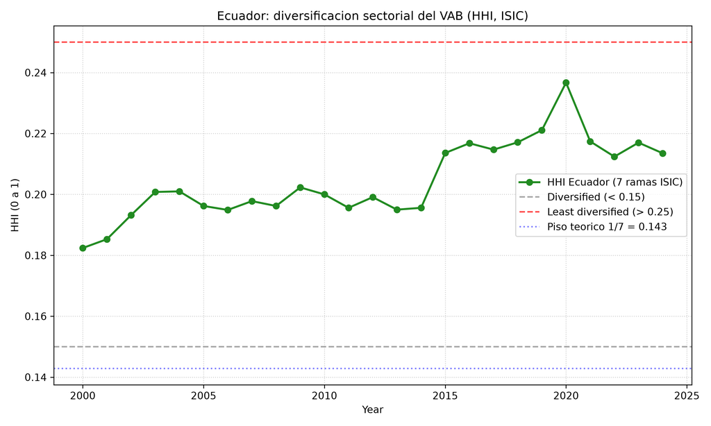

Tendencia del HHI sectorial de Ecuador, 2000–2024

## 6.2 Eficiencia técnica (DEA)

|  | model | dmu | n_inputs | n_outputs | n_dmu | threshold_3x | verdict | n_efficient | mean_efficiency | inputs_used | outputs_used | coverage_note |
| --- | --- | --- | --- | --- | --- | --- | --- | --- | --- | --- | --- | --- |
| 0 | Ecuador_Production_Frontier_DEA | sector-year | 2 | 1 | 42 | 9 | VALIDO | 4 | 0.6519 | input_employment, input_capital_fbkf | output_value_added | Panel sector-año 2018-2023; trabajo (empleo) y... |

El modelo de frontera de producción incluye 42 DMU (7 ramas × 6 años), 2 insumos y 1 producto, con un umbral de adecuación de 9; el veredicto es **válido**. La eficiencia media es 0,652 y cuatro DMU operan sobre la frontera. La lectura sectorial, promediando los años por rama, ordena la eficiencia técnica relativa:

|  | factor | mean_efficiency_sector |
| --- | --- | --- |
| 0 | Construction | 0.937313 |
| 1 | Mining & utilities | 0.913275 |
| 2 | Trade, restaurants & hotels | 0.800986 |
| 3 | Other activities | 0.590973 |
| 4 | Manufacturing | 0.558110 |
| 5 | Transport & communication | 0.507340 |
| 6 | Agriculture, forestry & fishing | 0.255303 |

Construcción (0,937) y minería-utilities (0,913) operan cerca de la frontera, seguidas por comercio-hoteles (0,801). En el extremo opuesto, agricultura (0,255) y transporte-comunicación (0,507) presentan la menor eficiencia técnica en la transformación de trabajo y capital en valor agregado.

## 6.3 Inferencia bootstrap (corrección de sesgo e intervalos)

|  | dmu | factor | year | efficiency_ccr_input | bias | efficiency_bias_corrected | ci_low | ci_high |
| --- | --- | --- | --- | --- | --- | --- | --- | --- |
| 0 | Construction_2023 | Construction | 2023 | 1.0000 | 0.1406 | 0.8594 | 0.7539 | 0.9181 |
| 1 | Construction_2021 | Construction | 2021 | 1.0000 | 0.1814 | 0.8186 | 0.6593 | 0.9093 |
| 2 | Construction_2019 | Construction | 2019 | 0.9567 | 0.1438 | 0.8129 | 0.6922 | 0.8794 |
| 3 | Trade, restaurants & hotels_2020 | Trade, restaurants & hotels | 2020 | 0.9640 | 0.1559 | 0.8081 | 0.6456 | 0.8898 |
| 4 | Construction_2022 | Construction | 2022 | 0.9085 | 0.1230 | 0.7855 | 0.6935 | 0.8382 |
| 5 | Mining & utilities_2019 | Mining & utilities | 2019 | 1.0000 | 0.2274 | 0.7726 | 0.4234 | 0.9099 |
| 6 | Construction_2018 | Construction | 2018 | 0.8620 | 0.1088 | 0.7532 | 0.6775 | 0.7965 |
| 7 | Construction_2020 | Construction | 2020 | 0.8967 | 0.1524 | 0.7443 | 0.6086 | 0.8204 |
| 8 | Mining & utilities_2018 | Mining & utilities | 2018 | 0.9466 | 0.2036 | 0.7430 | 0.4221 | 0.8662 |
| 9 | Mining & utilities_2022 | Mining & utilities | 2022 | 1.0000 | 0.2896 | 0.7104 | 0.3291 | 0.9096 |
| 10 | Trade, restaurants & hotels_2021 | Trade, restaurants & hotels | 2021 | 0.8394 | 0.1406 | 0.6988 | 0.5620 | 0.7733 |
| 11 | Mining & utilities_2021 | Mining & utilities | 2021 | 0.9259 | 0.2389 | 0.6870 | 0.3517 | 0.8483 |
| 12 | Trade, restaurants & hotels_2022 | Trade, restaurants & hotels | 2022 | 0.7751 | 0.1170 | 0.6581 | 0.5567 | 0.7122 |
| 13 | Mining & utilities_2023 | Mining & utilities | 2023 | 0.9030 | 0.2515 | 0.6515 | 0.3073 | 0.8300 |
| 14 | Trade, restaurants & hotels_2023 | Trade, restaurants & hotels | 2023 | 0.7406 | 0.1036 | 0.6370 | 0.5587 | 0.6806 |
| 15 | Trade, restaurants & hotels_2018 | Trade, restaurants & hotels | 2018 | 0.7397 | 0.1235 | 0.6161 | 0.4948 | 0.6818 |
| 16 | Trade, restaurants & hotels_2019 | Trade, restaurants & hotels | 2019 | 0.7471 | 0.1321 | 0.6150 | 0.4961 | 0.6846 |
| 17 | Other activities_2020 | Other activities | 2020 | 0.6763 | 0.0835 | 0.5928 | 0.5236 | 0.6263 |
| 18 | Mining & utilities_2020 | Mining & utilities | 2020 | 0.7042 | 0.1548 | 0.5493 | 0.3221 | 0.6432 |
| 19 | Transport & communication_2018 | Transport & communication | 2018 | 0.6037 | 0.0682 | 0.5354 | 0.4894 | 0.5594 |
| 20 | Manufacturing_2018 | Manufacturing | 2018 | 0.5993 | 0.0685 | 0.5308 | 0.4867 | 0.5551 |
| 21 | Other activities_2023 | Other activities | 2023 | 0.6069 | 0.0859 | 0.5210 | 0.4339 | 0.5611 |
| 22 | Transport & communication_2019 | Transport & communication | 2019 | 0.5738 | 0.0655 | 0.5082 | 0.4632 | 0.5316 |
| 23 | Other activities_2021 | Other activities | 2021 | 0.5880 | 0.0814 | 0.5066 | 0.4254 | 0.5440 |
| 24 | Other activities_2022 | Other activities | 2022 | 0.5857 | 0.0824 | 0.5033 | 0.4197 | 0.5417 |
| 25 | Manufacturing_2021 | Manufacturing | 2021 | 0.5676 | 0.0648 | 0.5028 | 0.4608 | 0.5258 |
| 26 | Manufacturing_2023 | Manufacturing | 2023 | 0.5605 | 0.0633 | 0.4972 | 0.4544 | 0.5194 |
| 27 | Manufacturing_2022 | Manufacturing | 2022 | 0.5525 | 0.0624 | 0.4901 | 0.4480 | 0.5120 |
| 28 | Other activities_2019 | Other activities | 2019 | 0.5681 | 0.0798 | 0.4883 | 0.4076 | 0.5254 |
| 29 | Manufacturing_2020 | Manufacturing | 2020 | 0.5493 | 0.0638 | 0.4855 | 0.4448 | 0.5084 |
| 30 | Transport & communication_2020 | Transport & communication | 2020 | 0.5399 | 0.0616 | 0.4784 | 0.4363 | 0.5003 |
| 31 | Manufacturing_2019 | Manufacturing | 2019 | 0.5195 | 0.0589 | 0.4606 | 0.4214 | 0.4814 |
| 32 | Other activities_2018 | Other activities | 2018 | 0.5208 | 0.0776 | 0.4432 | 0.3668 | 0.4800 |
| 33 | Transport & communication_2021 | Transport & communication | 2021 | 0.4931 | 0.0579 | 0.4352 | 0.3935 | 0.4564 |
| 34 | Transport & communication_2023 | Transport & communication | 2023 | 0.4392 | 0.0552 | 0.3840 | 0.3366 | 0.4066 |
| 35 | Transport & communication_2022 | Transport & communication | 2022 | 0.3944 | 0.0519 | 0.3425 | 0.2948 | 0.3652 |
| 36 | Agriculture, forestry & fishing_2023 | Agriculture, forestry & fishing | 2023 | 0.2746 | 0.0374 | 0.2372 | 0.2093 | 0.2532 |
| 37 | Agriculture, forestry & fishing_2018 | Agriculture, forestry & fishing | 2018 | 0.2589 | 0.0361 | 0.2228 | 0.1955 | 0.2380 |
| 38 | Agriculture, forestry & fishing_2021 | Agriculture, forestry & fishing | 2021 | 0.2544 | 0.0355 | 0.2189 | 0.1915 | 0.2339 |
| 39 | Agriculture, forestry & fishing_2019 | Agriculture, forestry & fishing | 2019 | 0.2494 | 0.0355 | 0.2139 | 0.1873 | 0.2289 |
| 40 | Agriculture, forestry & fishing_2022 | Agriculture, forestry & fishing | 2022 | 0.2449 | 0.0324 | 0.2125 | 0.1885 | 0.2262 |
| 41 | Agriculture, forestry & fishing_2020 | Agriculture, forestry & fishing | 2020 | 0.2496 | 0.0406 | 0.2090 | 0.1730 | 0.2289 |

|  | metrica | valor |
| --- | --- | --- |
| 0 | eficiencia media DEA | 0.6519 |
| 1 | eficiencia media corregida | 0.5462 |

La corrección por sesgo confirma el sesgo determinista al alza: todas las DMU reciben una eficiencia corregida estrictamente menor que la estimación DEA, y las cuatro DMU originalmente eficientes ($\theta=1$) bajan de la frontera (por ejemplo, Construcción 2023 pasa de 1,000 a 0,859, con un intervalo de confianza al 95% de [0,754; 0,918]). La eficiencia media corregida es sustancialmente inferior a la estimación puntual. Las comparaciones entre ramas solo deben considerarse robustas cuando sus bandas de confianza no se solapan: la brecha entre agricultura (banda superior en torno a 0,25) y los sectores líderes es inequívoca, mientras que diferencias dentro del bloque intermedio (manufactura, transporte, otras actividades) son estadísticamente menos nítidas.

# 7 Discusión

Los resultados ofrecen un diagnóstico coherente. Por un lado, el HHI muestra que Ecuador no ha avanzado hacia una mayor diversificación en lo que va del siglo; si acaso, la concentración aumentó moderadamente. Esto es consistente con la literatura que documenta la persistencia de estructuras primario-exportadoras en economías dependientes de recursos (Lederman & Maloney, 2007; Sachs & Warner, 1995; UNCTAD, 2019) y con la trayectoria no monótona de la diversificación descrita por Imbs & Wacziarg (2003) y Cadot et al. (2011), en la que economías de ingreso medio pueden estancar su proceso de diversificación.

Por otro lado, el DEA revela que la eficiencia técnica es marcadamente heterogénea entre sectores. Que la agricultura —intensiva en empleo y de baja productividad relativa— quede rezagada, mientras minería-utilities opera cerca de la frontera, ilustra la tensión central del desarrollo ecuatoriano: los sectores más eficientes en el uso de factores no son necesariamente los más diversificados ni los que generan más empleo de calidad. La eficiencia de la construcción debe leerse con cautela, pues es sensible al ciclo de inversión pública y privada.

La corrección de Simar–Wilson es metodológicamente decisiva: sin ella, las eficiencias DEA sobreestiman sistemáticamente el desempeño y cualquier ordenamiento entre sectores cercanos carecería de respaldo inferencial. Al delimitar intervalos, el análisis distingue las diferencias robustas de las que son producto del ruido muestral.

# 8 Conclusiones e implicaciones de política

Este trabajo replicó y extendió el marco de Siddiqui & Afzal (2022) para Ecuador, integrando una medición de concentración con poder discriminante, un DEA de frontera de producción correctamente especificado e inferencia bootstrap. Tres conclusiones se desprenden. Primera, Ecuador es una economía moderadamente diversificada cuya concentración sectorial aumentó levemente entre 2000 y 2024. Segunda, la eficiencia técnica es heterogénea: construcción y minería-utilities lideran, agricultura y transporte-comunicación quedan rezagadas. Tercera, la corrección por sesgo es indispensable para una lectura inferencial honesta.

En términos de política, los hallazgos respaldan una estrategia de transformación productiva que (i) eleve la eficiencia de los sectores intensivos en empleo —en particular la agricultura— mediante tecnología, capital y encadenamientos; (ii) aproveche la eficiencia de los sectores líderes para financiar la diversificación, evitando que la concentración se profundice; y (iii) fortalezca las capacidades de complejidad económica (Hausmann et al., 2007; Hidalgo & Hausmann, 2009) como vía de largo plazo. La política industrial moderna sugiere combinar incentivos horizontales con apuestas selectivas sujetas a evaluación (Benhassine et al., 2019; Rodrik, 2004).

# 9 Limitaciones y agenda futura

El análisis tiene límites que acotan su interpretación. El DEA identifica posiciones relativas de eficiencia técnica bajo rendimientos constantes a escala, no relaciones causales. La ventana del panel de eficiencia (2018–2023) está condicionada por la cobertura de la FBKF armonizada. Las exportaciones, una dimensión central de la diversificación, aún no se incorporan al DEA porque la evidencia oficial del BCE se organiza por productos y países, no por ramas equivalentes a la partición ISIC; el pipeline ya está preparado para incorporarlas como segundo producto en cuanto exista una serie por rama verificada. La agenda futura incluye: (i) extender el horizonte temporal del panel de eficiencia; (ii) incorporar exportaciones y capital humano como productos adicionales; (iii) aplicar la regresión truncada en dos etapas de Simar & Wilson (2007) para explicar la (in)eficiencia con covariables; y (iv) complementar el análisis con modelos de cambio estructural y series de tiempo sobre el vínculo entre diversificación y crecimiento.

# Referencias

Adewuyi, A. O., & Awodumi, O. B. (2017). Biomass energy consumption, economic growth and carbon emissions: Fresh evidence from West Africa. *Energy Economics*, *61*, 31-44. https://doi.org/10.1016/j.eneco.2016.11.005

Adjasi, C., Alhassan, A. L., & Harvey, S. (2024). Financial development and economic diversification in Africa. *Journal of African Economies*.

Asratie, T. M., & Mazengia, D. H. (2023). Determinants of export diversification in Ethiopia. *Cogent Economics & Finance*, *11*(1).

Banco Central del Ecuador. (2024a). *Cuentas Nacionales Anuales: Formación Bruta de Capital Fijo por industria 1965–2024p*. Banco Central del Ecuador.

Banco Central del Ecuador. (2024b). *Cuentas Nacionales Anuales: Matriz de Empleo e Ingresos (MEI) 2018–2024p*. Banco Central del Ecuador.

Banker, R. D., Charnes, A., & Cooper, W. W. (1984). Some models for estimating technical and scale inefficiencies in data envelopment analysis. *Management Science*, *30*(9), 1078-1092. https://doi.org/10.1287/mnsc.30.9.1078

Bekhzad, K. (2011). Economic diversification in resource-rich transition economies. *Working Paper*.

Benhassine, N., Raballand, G., et al. (2019). Industrial policy and economic diversification in developing countries. *World Bank Policy Research*.

Cadot, O., Carrère, C., & Strauss-Kahn, V. (2011). Export diversification: What’s behind the hump? *The Review of Economics and Statistics*, *93*(2), 590-605. https://doi.org/10.1162/REST_a_00078

Charnes, A., Cooper, W. W., & Rhodes, E. (1978). Measuring the efficiency of decision making units. *European Journal of Operational Research*, *2*(6), 429-444. https://doi.org/10.1016/0377-2217(78)90138-8

Coelli, T. J., Rao, D. S. P., O’Donnell, C. J., & Battese, G. E. (2005). *An Introduction to Efficiency and Productivity Analysis* (2.ª ed.). Springer.

Cooper, W. W., Seiford, L. M., & Tone, K. (2007). *Data Envelopment Analysis: A Comprehensive Text with Models, Applications, References and DEA-Solver Software* (2.ª ed.). Springer.

Farrell, M. J. (1957). The measurement of productive efficiency. *Journal of the Royal Statistical Society: Series A (General)*, *120*(3), 253-290. https://doi.org/10.2307/2343100

Gaiano, M. (2010). Estructura productiva y diversificación económica en América Latina. *Working Paper*.

Gyebi, F. et al. (2017). Export diversification and economic growth in developing economies. *Journal of Economics and Sustainable Development*.

Gylfason, T. (2001). Natural resources, education, and economic development. *European Economic Review*, *45*(4–6), 847-859. https://doi.org/10.1016/S0014-2921(01)00127-1

Hausmann, R., Hwang, J., & Rodrik, D. (2007). What you export matters. *Journal of Economic Growth*, *12*(1), 1-25. https://doi.org/10.1007/s10887-006-9009-4

Herfindahl, O. C. (1950). *Concentration in the Steel Industry*. Columbia University, Ph.D. dissertation.

Hesse, H. (2008). *Export Diversification and Economic Growth* (Working Paper No. 21). Commission on Growth; Development.

Hidalgo, C. A., & Hausmann, R. (2009). The building blocks of economic complexity. *Proceedings of the National Academy of Sciences*, *106*(26), 10570-10575. https://doi.org/10.1073/pnas.0900943106

Hirschman, A. O. (1964). The paternity of an index. *The American Economic Review*, *54*(5), 761-762.

Hodey, L. S., Oduro, A. D., & Senadza, B. (2019). Export diversification and economic growth in Sub-Saharan Africa. *Journal of African Development*.

Imbs, J., & Wacziarg, R. (2003). Stages of diversification. *The American Economic Review*, *93*(1), 63-86. https://doi.org/10.1257/000282803321455160

Islam, Md. S. et al. (2023). Export diversification, structural transformation and economic growth. *Economic Change and Restructuring*.

Jovović, R. (2020). Economic diversification and competitiveness of small economies. *Montenegrin Journal of Economics*.

Kuznets, S. (1955). Economic growth and income inequality. *The American Economic Review*, *45*(1), 1-28.

Lederman, D., & Maloney, W. F. (Eds.). (2007). *Natural Resources: Neither Curse nor Destiny*. World Bank; Stanford University Press.

Lewis, W. A. (1954). Economic development with unlimited supplies of labour. *The Manchester School*, *22*(2), 139-191. https://doi.org/10.1111/j.1467-9957.1954.tb00021.x

Niyimbanira, F. et al. (2022). Sectoral economic growth and employment in a developing economy. *International Journal of Economics and Finance Studies*.

Prebisch, R. (1950). The Economic Development of Latin America and Its Principal Problems. *United Nations, Economic Commission for Latin America*.

Rivera Velasco, J. L. (2025). Diversificación productiva y desarrollo económico en Ecuador. *Revista de Economía y Política*.

Rodrik, D. (2004). Industrial policy for the twenty-first century. *CEPR Discussion Paper*, (4767).

Sachs, J. D., & Warner, A. M. (1995). *Natural Resource Abundance and Economic Growth* (NBER Working Paper No. 5398). National Bureau of Economic Research. https://doi.org/10.3386/w5398

Santos-Paulino, A. U. (2010). Trade specialization, export productivity and growth in developing countries. *United Nations University-WIDER Working Paper*.

Sari, R., Ewing, B. T., et al. (2025). Energy, output and structural change in resource-dependent economies. *Energy Economics*.

Siddiqui, S. A., & Afzal, M. N. I. (2022). Sectoral diversification of the UAE toward a knowledge-based economy. *Review of Economics and Political Science*, *7*(3), 177-193. https://doi.org/10.1108/REPS-07-2021-0075

Simar, L., & Wilson, P. W. (1998). Sensitivity analysis of efficiency scores: How to bootstrap in nonparametric frontier models. *Management Science*, *44*(1), 49-61. https://doi.org/10.1287/mnsc.44.1.49

Simar, L., & Wilson, P. W. (2007). Estimation and inference in two-stage, semi-parametric models of production processes. *Journal of Econometrics*, *136*(1), 31-64. https://doi.org/10.1016/j.jeconom.2005.07.009

UNCTAD. (2019). *Commodity Dependence: A Twenty-Year Perspective*. United Nations Conference on Trade; Development.

United Nations Statistics Division. (2024). *National Accounts Main Aggregates Database: GDP and its breakdown at current prices*. UNSD AMA API.

Yaya, K., Kéita, S., & Coulibaly, S. (2018). Trade openness and economic growth: Evidence from developing countries. *Cogent Economics & Finance*, *6*(1).